# Homework 8

Kayla

November 5, 2020

# R Markdown Fun

For this homework, I am going to plot some of the data that I manipulated in the Allegheny County Dog Licenses dataset. I have pulled this dataset into a dataframe, below.

```r
allegheny_county_dog_licenses <- read.csv("allegheny_county_dog_licenses.csv", stringsAsFactors=FALSE)
head(allegheny_county_dog_licenses)
```

```
##                  LicenseType              Breed             Color DogName
## 1 Dog Lifetime Spayed Female LABRADOR RETRIEVER            YELLOW   SASHA
## 2 Dog Lifetime Neutered Male LABRADOR RETRIEVER             BROWN    JAKE
## 3 Dog Lifetime Spayed Female              MIXED           SPOTTED  SHILOH
## 4 Dog Lifetime Spayed Female            LAB MIX             BROWN BLONDIE
## 5 Dog Lifetime Spayed Female       AUS SHEPHERD             MULTI   SASHA
## 6          Dog Lifetime Male         ENG SETTER WHITE/BLACK/BROWN    CODY
##   OwnerZip ExpYear           ValidDate
## 1    15137    2099 2005-01-31T00:00:00
## 2    15129    2099 2004-06-21T00:00:00
## 3    15129    2099 2006-01-20T00:00:00
## 4    15140    2099 2005-07-18T00:00:00
## 5    15238    2099 2004-02-25T00:00:00
## 6    15037    2099 2006-02-24T00:00:00
```

## Rosie Dogs!

Because my family has a lovely goldendoodle named Rosie, the first thing I wanted to look at was dogs named Rosie in Allegheny County. To do so, I pulled created a true/false vector that pulled out dogs with the name Rosie, or some variation of that name. I summed it to discover that there are 121 dogs named Rosie in AC. I then put this into a separate dataframe.

```
## [1] 121
```

```
##                     LicenseType        Breed       Color   DogName OwnerZip
## 136  Dog Lifetime Spayed Female   GREAT DANE       OTHER     ROSIE    15202
## 227  Dog Lifetime Spayed Female      MALTESE       WHITE     ROSIE    15106
## 891  Dog Lifetime Spayed Female SHEPHERD MIX WHITE/BROWN     ROSIE    15068
## 1006 Dog Senior Lifetime Female        MIXED       MULTI     ROSIE    15243
## 1073 Dog Lifetime Spayed Female        MIXED   BLACK/TAN  ROSIE JO    15237
## 1323 Dog Lifetime Spayed Female    CHIHUAHUA       BROWN ROSIE SUE    15146
##      ExpYear           ValidDate
## 136     2099 2004-03-19T00:00:00
## 227     2099 2004-06-24T00:00:00
## 891     2099 2019-02-27T09:34:06
## 1006    2099 2015-07-13T12:09:55
## 1073    2099 2015-07-21T09:55:20
## 1323    2099 2015-08-27T15:56:41
```

## Goldendoodles!

The next thing I did was pull out dogs named Rosie that are goldendoodles. To do so, I made a true/false vector to sort for the breed “GOLDENDOODLE” and applied it to the Rosie dataframe. I then summed it to discover there are 8 goldendoodles in AC.

```r
doodle_rosie_tf <- str_detect(rosie_df$Breed, "GOLDENDOODLE") # from dogs named Rosie, pull out goldendoodles
sum(doodle_rosie_tf) # there are 8, double hooray!
```

```
## [1] 8
```

```r
doodle_rosie_df <- rosie_df[doodle_rosie_tf, ] # create df
head(doodle_rosie_df)
```

```
##                      LicenseType        Breed  Color DogName OwnerZip ExpYear
## 9466  Dog Lifetime Spayed Female GOLDENDOODLE  BROWN   ROSIE    15090    2099
## 11049 Dog Lifetime Spayed Female GOLDENDOODLE  CREAM   ROSIE    15101    2099
## 17177 Dog Lifetime Spayed Female GOLDENDOODLE BLONDE   ROSIE    15101    2099
## 18441 Dog Lifetime Spayed Female GOLDENDOODLE  BROWN   ROSIE    15243    2099
## 21239 Dog Lifetime Spayed Female GOLDENDOODLE    RED   ROSIE    15108    2099
## 22742 Dog Lifetime Spayed Female GOLDENDOODLE  BROWN   ROSIE    15241    2099
##                 ValidDate
## 9466  2019-08-28T13:35:56
## 11049 2011-03-08T14:07:19
## 17177 2018-02-05T14:08:21
## 18441 2018-02-14T11:09:26
## 21239 2014-09-08T15:24:44
## 22742 2020-09-10T11:01:19
```

## Let’s plot!

Next, I decided to plot my 8 happy doods named Rosie.

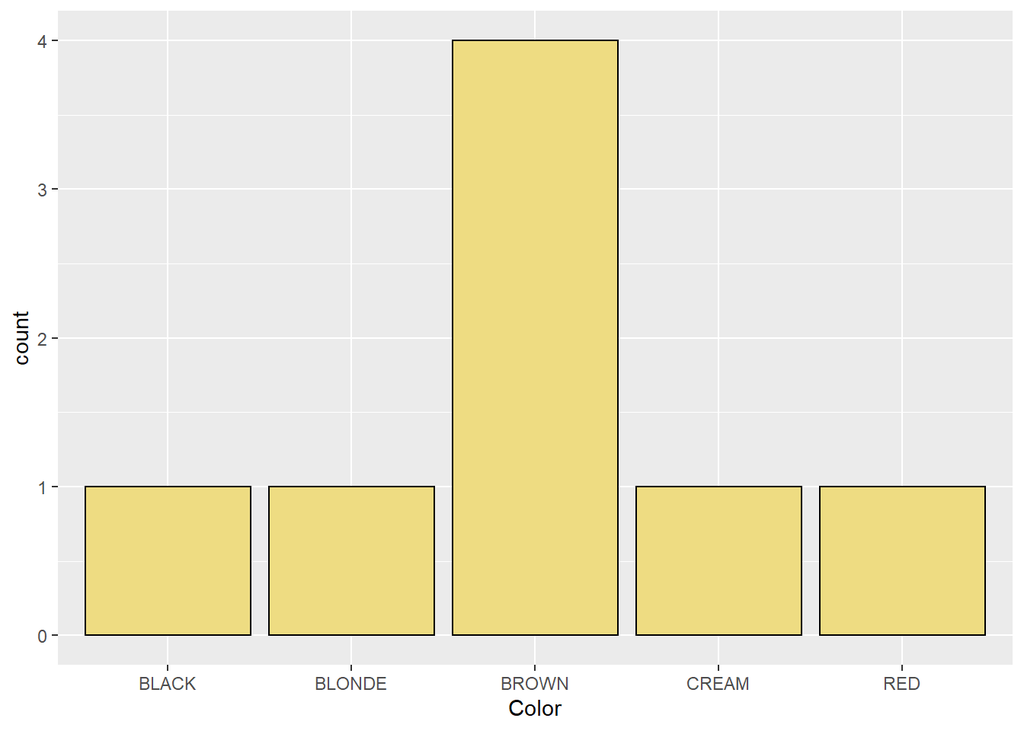

```r
library('ggplot2')

ggplot(data = doodle_rosie_df, aes(x=Color))+
  geom_bar(color="black", fill="lightgoldenrod2")
```

## Rosalies! (Or lack thereof …)

My Rosie’s full name is Rosalie, but she lives in Washington County with my parents. I decided to see if she has an Allegheny County counterpart. First, I created a true/false vector to check the original dataset for dogs named Rosalie.

```r
rosalie_tf <- str_detect(allegheny_county_dog_licenses$DogName, "ROSALIE") #pull out dogs named Rosalie
sum(rosalie_tf)
```

```
## [1] 0
```

There are no dogs in Allegheny County names Rosalie! My Rosie is [truly unique](https://www.instagram.com/rosaliethedoodle/).

## Lhasa Apso Data!

Next, I decided to look at data for dogs that are a Lhasa Apso mix. My family had a loyal little Lhasa Apso Poodle mix named [Oreo](https://www.instagram.com/p/B9mC0uvhBk5/) for 15 years.

```r
# Pull out all the Lhasa Apso mixes
lhasa_mix_tf <- str_detect(allegheny_county_dog_licenses$Breed, "LHASA APSO MIX")
sum(lhasa_mix_tf) # there are 21 Lhasa Apso mixes
```

```
## [1] 21
```

```r
lhasa_mix_df <- allegheny_county_dog_licenses[lhasa_mix_tf,]
```

## Fun with Names!

With such a small dataframe, let’s look at their names

```r
lhasa_mix_names <- unique(lhasa_mix_df$DogName) # pull out unique names into a vector
lhasa_mix_names
```

```
##  [1] "JUNGEE"      "MISSY MOYER" "ZUZU"        "SAMPSON"     "LOLA"
##  [6] "HALEY"       "GINGER"      "MAX"         "ETHEL"       "BUDDY"
## [11] "CHARLIE"     "BENJI"       "LIBBY"       "HAILEY"      "BOE"
## [16] "D-JAY"       "MIA"         "CHICKIE"     "COOPER"      "RUBY"
## [21] "PEPSI"
```

```r
length(lhasa_mix_names)
```

```
## [1] 21
```

There are 21 Lhasa Apso mixes in Allegheny County and when we run unique on the DogName column, we get 21 names. This means each Lhasa Apso mix in Allegheny County has a unique name. While this is cute, we can’t plot much with this. So, let’s look at something else! Instead, I will compare Lhasa Apsos and Lhasa Apso mixes.

```r
# pull out all dog breeds with "Lhasa" in the breed name
all_lhasas_tf <- str_detect(allegheny_county_dog_licenses$Breed, "LHASA")
sum(all_lhasas_tf)
```

```
## [1] 102
```

```r
# pull all Lhasas into a dataframe
all_lhasas_df <- allegheny_county_dog_licenses[all_lhasas_tf,]
all_lhasas_df
```

```
##                                 LicenseType          Breed             Color
## 45               Dog Lifetime Neutered Male     LHASA APSO             BEIGE
## 796              Dog Lifetime Spayed Female     LHASA APSO       WHITE/BLACK
## 1250      Dog Senior Lifetime Spayed Female LHASA APSO MIX            BLONDE
## 1557             Dog Lifetime Spayed Female     LHASA APSO         BLACK/TAN
## 1713             Dog Lifetime Neutered Male     LHASA APSO       WHITE/BROWN
## 2160             Dog Lifetime Spayed Female     LHASA APSO         WHITE/TAN
## 2394      Dog Senior Lifetime Spayed Female     LHASA APSO      WHITE/YELLOW
## 3245                 Dog Lifetime Duplicate     LHASA APSO             WHITE
## 3953                 Dog Lifetime Duplicate     LHASA APSO WHITE/BLACK/BROWN
## 4302             Dog Lifetime Spayed Female LHASA APSO MIX             CREAM
## 4406             Dog Lifetime Spayed Female     LHASA APSO         TRI-COLOR
## 4561      Dog Senior Lifetime Spayed Female LHASA APSO MIX             BLACK
## 4721      Dog Senior Lifetime Neutered Male LHASA APSO MIX       WHITE/BLACK
## 4914             Dog Lifetime Spayed Female     LHASA APSO       WHITE/BROWN
```

[output cut: 191 more lines]

## Let’s plot!

Now we have both purebred Lhasa Apsos and Lhasa Apso mixes in a data frame.

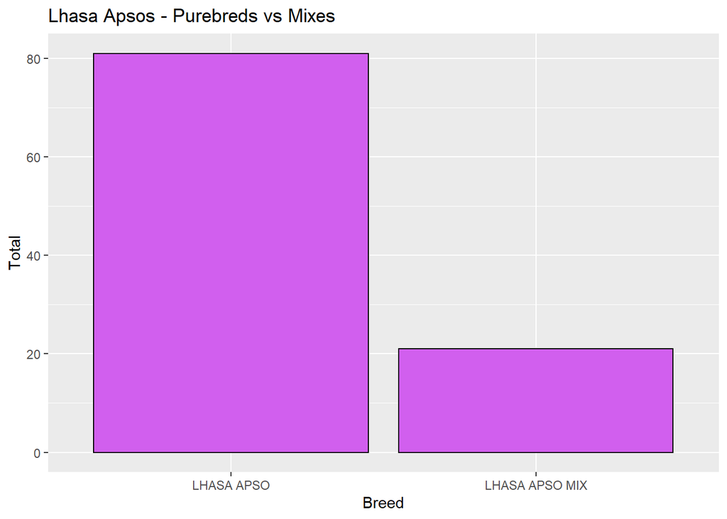

```r
ggplot(data = all_lhasas_df, aes(x=Breed))+
  geom_bar(color="black", fill="mediumorchid2")+
  ggtitle("Lhasa Apsos - Purebreds vs Mixes")+
  ylab("Total")
```

Obviously, we have a lot more purebred Lhasa Apso dogs than mixes in Allegheny County!